# Coursera Data Science Milestone

Alberto Poncelas

## Introduction

The goal of this document is to make an exploratory data analysis for the data provided by the Coursera Data Science Specialization.

## The data and Sampling

The data consist on three files with texts in English obtained from different sources: blogs, news and twitter.

The size of the files are:

- News: 1,010,242 lines.
- Tweets: 2,360,148 lines.
- Blog: 899,288 lines.

To perform an analysis of the texts we are going to take a sample of 150,000 lines each text. Then we are going to extract all the words from all sentences.

The number of words extracted from the different files are:

- News: Extracted 5115948 words (183065 different words).
- Tweets: Extracted 1902531 words (113284 different words).
- Blog: Extracted 6179348 words (211753 different words).

In total, 13197827 words have been extracted.

## Word distribution

The 20 most frequent words in the sampling are the following: “the, to, and, a, of, in, i, that, is, for, it, on, with, you, was, at, this, as, my, be”. We want t o know the distribution of the words, so we have the plot of the histogram and the histogram in log scale. Also we added the cumulative sum plot.

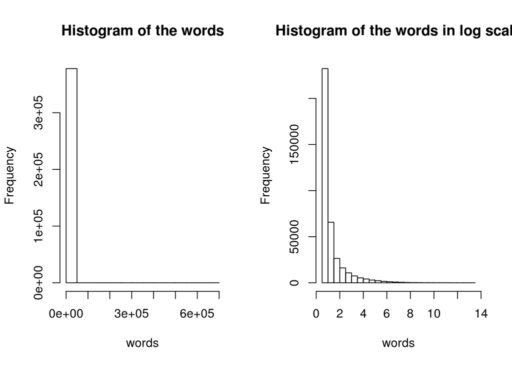

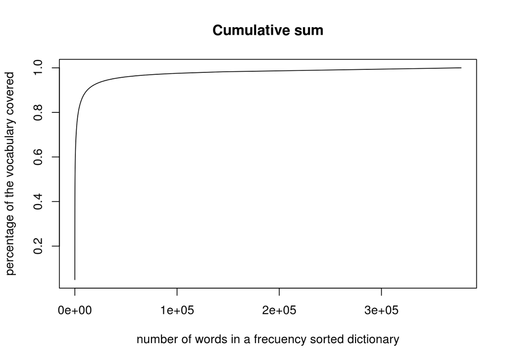

As we can see, there is a set of a few words with a higher frequency. In the last plot we can see the percentage of the vocabulary (meaning all the words in the sample) that is being covered as we increase the size of a frequency sorted dictionary. Just a few words are needed to cover a high percentage: We would need 167 words for covering 50% and 12145 for 90% of the vocabulary.

We are also interested in knowing whether the shortest words are the most frequent or not. For doing that so, we show the occurrences of the words by length (considering the words with more than 30 letters as outliers)

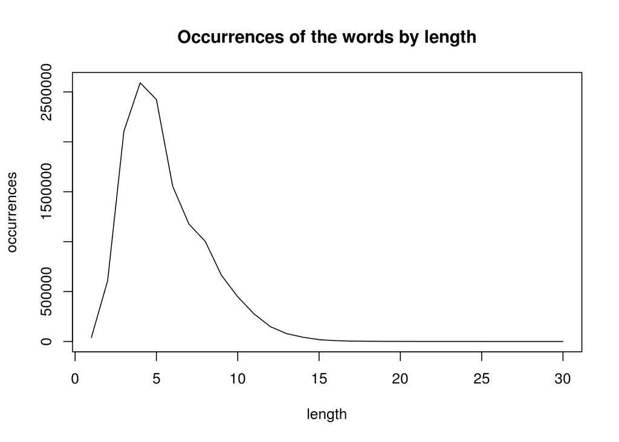

## Conclusions

In this document we have presented an analysis of the words in English language texts. We can conclude that a small set of words are much more frequent than the rest, and usually the most frequent words tend to be sorter.